# PyData London News March 2018

## Wifi: GST-Man, pw: xxx

```python
Image(filename="images/pydata_logo.png", width=600)
```

[output not shown]

# Pandas Documentation Sprint

- Saturday 10th March, from 10am
- 30+ locations world wide
- London chapter by Python Sprints, hosted at Bloomberg
- https://python-sprints.github.io/pandas/

```python
IFrame('https://python-sprints.github.io/pandas/', **default_size)
```

[interactive chart not shown]

# More PyData in the UK

- [PyData Bristol meetup](https://www.meetup.com/PyData-Bristol/) launched on 15th Feb, first meetup 15th March
- [PyData Edinburgh meetup](https://www.meetup.com/PyData-Edinburgh/) The first meetup was on 1st Feb
- [PyData Cardiff meetup](https://twitter.com/pydatacardiff)

[figure not shown]

```python
Image('images/pydata-bristol.png', **default_size)
```

# New Python conference: PyLondinium

- Supported by PSF
- 8-10 June (Fri sprints, Sat-Sun talks)
- Call for Proposals now open
- https://pylondinium.org/

```python
IFrame('https://pylondinium.org/', **default_size)
```

[interactive chart not shown]

# AHL Hackathon

- https://www.ahl.com/hackathon
- Hackathon to improve the Python Data Science
- **21-22 April** hosted by AHL

[figure not shown]

```python
Image('images/ahl-hackathon.png', **default_size)
```

# PyData London 2018

- https://pydata.org/london2018/
- **27-29 April 2018** at the **Tower Hotel**
- Fri: Tutorials; Sat-Sun: main event
- 3 parallel tracks, 1 unconference track (hackathon, sprints, etc.)
- Tickets now for sale

[figure not shown]

```python
Image('images/pydata_2018.png', **default_size)
```

## PyData London 2018 - Keynote Speakers

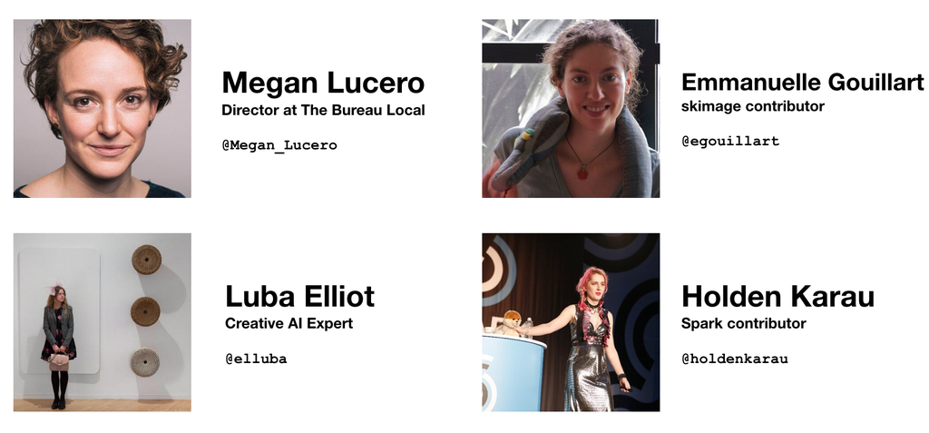

```python
Image('images/keynote-speakers.png', **default_size)
```

## More on PyData London 2018

- Proposals under review, programme schedule by the end of March
- Diversity Scholarship: [applications open](https://pydata.org/london2018/about/diversity-scholarships/)
- Childcare support
- Call for Volunteers (talk to Agata!)
- Unconference activities (TBC):
  - Algorithmic Art Hackathon (Tariq Rashid)
  - Politics Hackathon (John Sandall)
  - pandas sprint (Marc Garcia)
- Call for Sponsors

# POTM: JupyterLab Next-generation web-based interface for Jupyter

- IDE for working with notebooks, code and data
- Lightning talk later (thanks Steve!)

[figure not shown]

```python
Image('images/jupyterlab.png', **default_size)
```